# Nicolai_ex03

## Exercise 3

Markov’s inequality represents an upper boud to probability distributions:
$$P (X ≥ k) ≤ \frac{E[X]}{k} \quad for \ k>0$$
Having we defined a function:
$$G(k) = 1 − F (k) ≡ P (X ≥ k)$$
Plot G(k) and the Markov’s upper bound for: + The exponential, Exp(λ = 1), distribution function + The uniform, U (3, 5), distribution function + The binomial, Bin(n = 1, p = 1/2), distribution function + A Poisson, Pois(λ = 1/2), distribution function

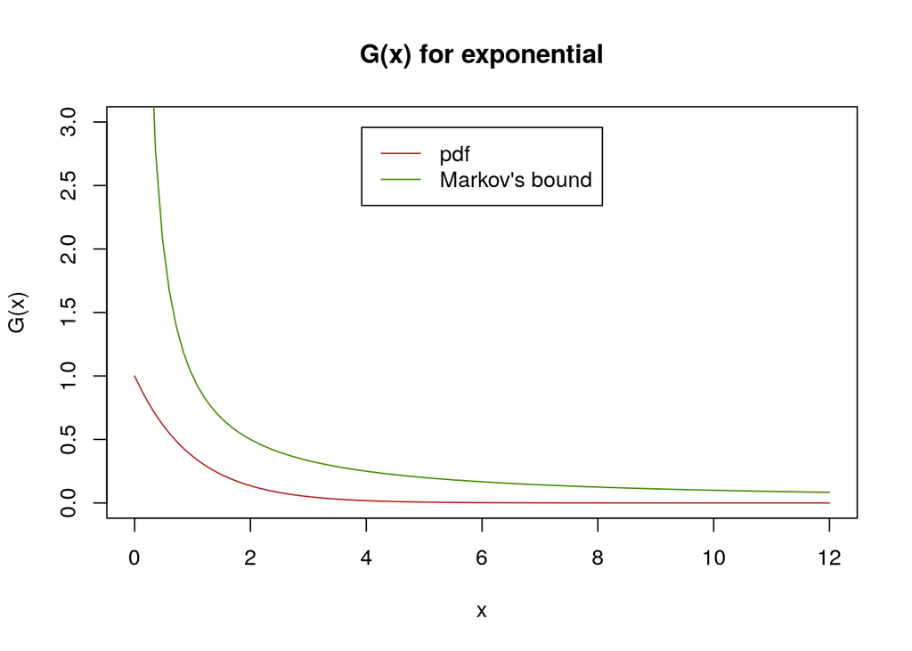

```r
curve((1 - pexp( x , rate = 1)), from = 0, to = 12, col = "firebrick", ylab = "G(x)", main = "G(x) for exponential", ylim = c(0,3))
curve( 1/x , from = 0, to = 12, add = TRUE, col = 'chartreuse4')
legend( x = "top", c("pdf", "Markov's bound") , col = c("firebrick", "chartreuse4"), lty=1,  inset = 0.05)
```

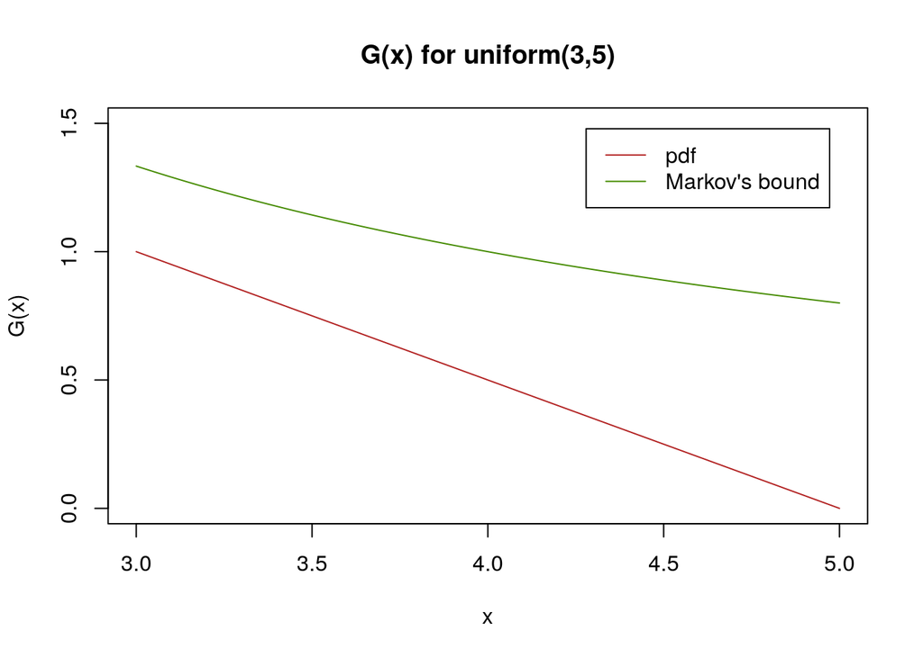

```r
curve((1 - punif(x,3,5)), from = 3, to = 5, col = "firebrick", ylab = "G(x)", main = "G(x) for uniform(3,5)", ylim = c(0,1.5))
curve( 4/x , from = 3, to = 5, add = TRUE, col = 'chartreuse4')
legend( x = "topright", c("pdf", "Markov's bound") , col = c("firebrick", "chartreuse4"), lty=1,  inset = 0.05)
```

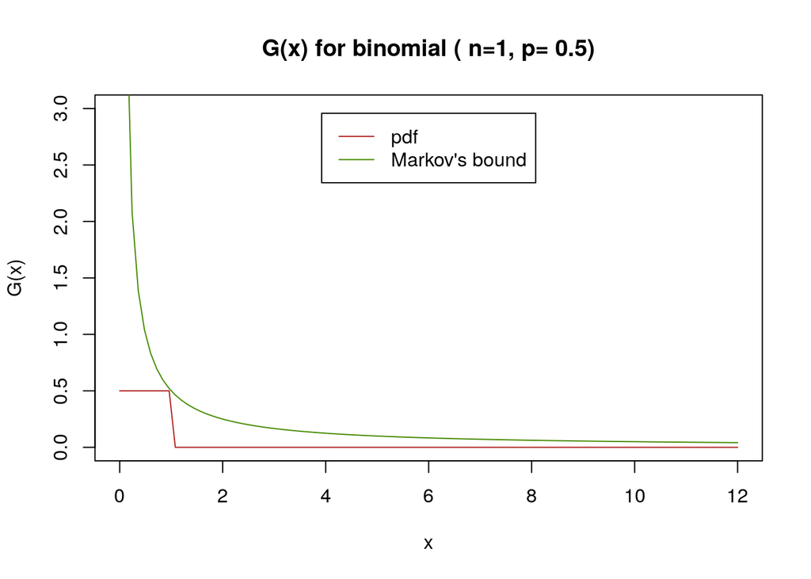

```r
curve((1 - pbinom(x, size = 1, prob = 1/2)), from = 0, to = 12, col = "firebrick", ylab = "G(x)", main = "G(x) for binomial ( n=1, p= 0.5)", ylim = c(0,3))
curve( 0.5/x , from = 0, to = 12, add = TRUE, col = 'chartreuse4')
legend( x = "top", c("pdf", "Markov's bound") , col = c("firebrick", "chartreuse4"), lty=1,  inset = 0.05)
```

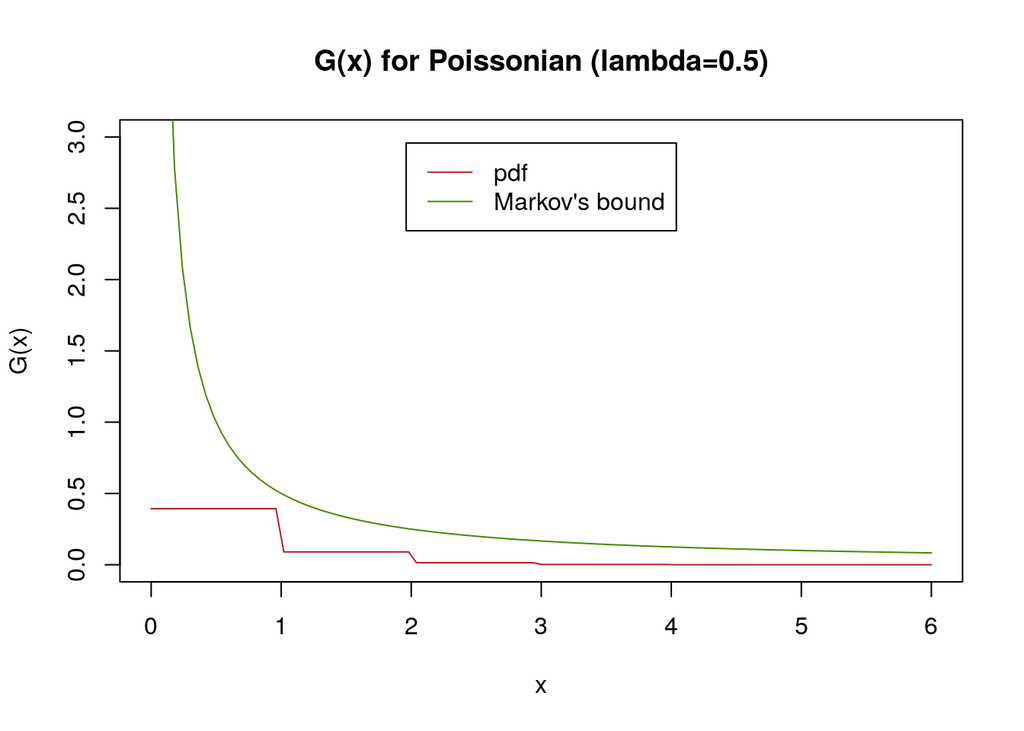

```r
curve((1 - ppois( x , lambda = 1/2)), from = 0, to = 6, col = "firebrick", ylab = "G(x)", main = "G(x) for Poissonian (lambda=0.5)", ylim = c(0, 3))
curve( 1/(2*x) , from = 0, to = 6, add = TRUE, col = 'chartreuse4')
legend( x = "top", c("pdf", "Markov's bound") , col = c("firebrick", "chartreuse4"), lty=1,  inset = 0.05)
```

## Exercise 4

Chebyshev’s inequality tells us that:
$$P ( |X − μ| ≥ kσ) ≤ \frac{1}{k^2}$$
which can be rewritten as:
$$P ( |X − μ| < kσ) ≥ 1 − \frac{1}{k^2}$$
Use R to show, with a plot, that Chebyshev’s inequality is is an upper bound to the following distributions:

- a normal distribution, N(μ = 3, σ = 5)
- an exponential distribution, Exp(λ = 1)
- a uniform distribution U (1 −√2, 1 + √2)
- a Poisson, Pois(λ = 1/3), distribution function

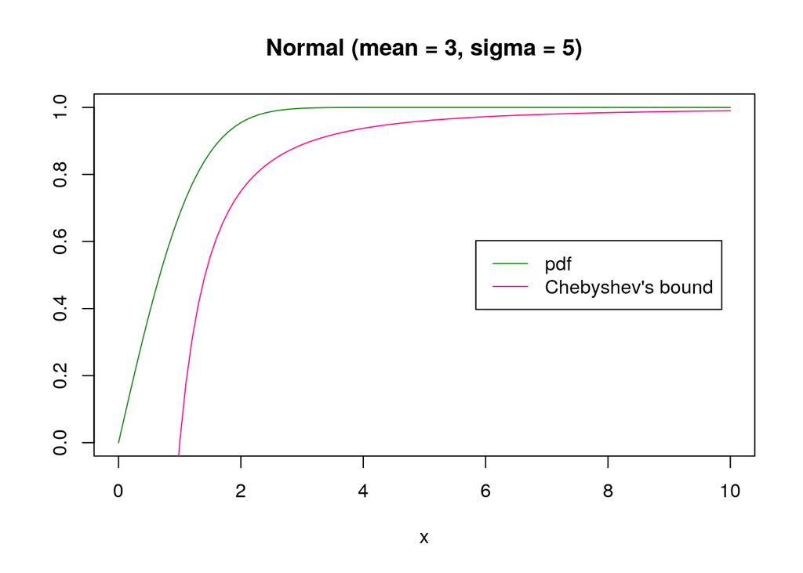

```r
curve(pnorm((5*x+3),3,5) - pnorm((3-5*x),3,5), 0, 10 , main = "Normal (mean = 3, sigma = 5)", col = "forestgreen",ylab= "")
curve(1-1/x^2, 0, 10, add=TRUE, col = 'deeppink')
legend( x = "right", c("pdf", "Chebyshev's bound") , col = c("forestgreen", "deeppink"), lty=1,  inset = 0.05)
```

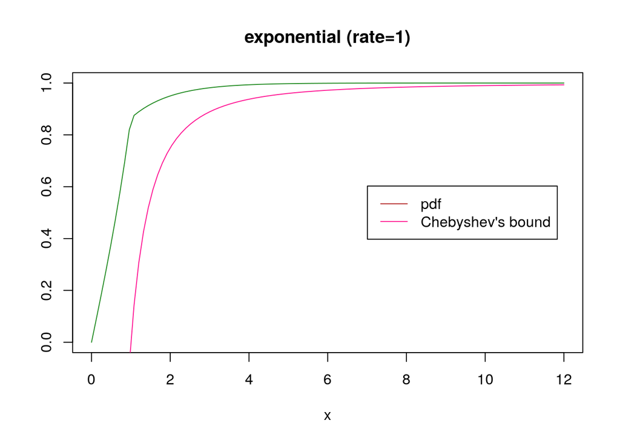

```r
curve((pexp(1+x, rate = 1) - pexp( 1-x , rate = 1)), from = 0, to = 12, col = "forestgreen", main = "exponential (rate=1)",ylab= "")
curve( 1- 1/(x^2) , from = 0, to = 12, add = TRUE, col = 'deeppink')
legend( x = "right", c("pdf", "Chebyshev's bound") , col = c("firebrick", "deeppink"), lty=1,  inset = 0.05)
```

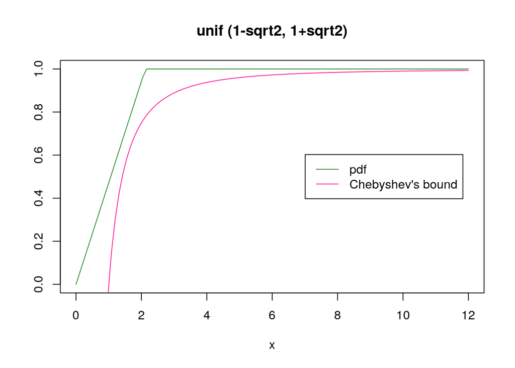

```r
curve(punif( 2*x/3 + 1 , 1-sqrt(2), 1+sqrt(2)) - punif( -2*x/3 + 1 , 1-sqrt(2), 1+sqrt(2)), from = 0, to = 12, col = "forestgreen", main = "unif (1-sqrt2, 1+sqrt2)", ylab= "")
curve( 1- 1/(x^2) , from = 0, to = 12, add = TRUE, col = 'deeppink')
legend( x = "right", c("pdf", "Chebyshev's bound") , col = c("forestgreen", "deeppink"), lty=1,  inset = 0.05)
```

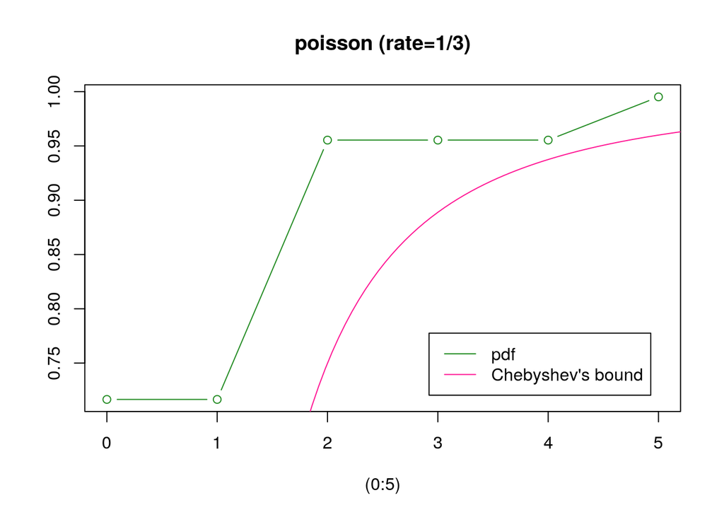

```r
plot( (0:5) , ppois((0:5)*(1/3) + 1/3, 1/3) , col = "forestgreen", main = "poisson (rate=1/3)", ylab= "", type = 'b')
curve( 1- 1/(x^2) , from = 0, to = 6, add = TRUE, col = 'deeppink')
legend( x = "bottomright", c("pdf", "Chebyshev's bound") , col = c("forestgreen", "deeppink"), lty=1,  inset = 0.05)
```